# Getting started with pomp

### Model checking with probes

Visual comparison of simulations and data is always a good idea. An indication that the data are not a plausible realization of the model is evidence for lack of fit. In particular, if we have any set of summary statistics, or *probes*, we can apply them to both simulated and actual data. The `probe` function facilitates this comparison. Let’s perform this operation using several of the summary statistics provided with **pomp**: we’ll use the mean, several quantiles, and the autocorrelation at lags 1 and 3.

```r
mlepomp |>
  probe(nsim=200,probes=list(
    mean=probe_mean("pop"),
    q=probe_quantile("pop",probs=c(0.05,0.25,0.5,0.75,0.95)),
    probe_acf("pop",lags=c(1,3),type="corr",transform=log)
  )) -> vp_probe

vp_probe
```

```
## <object of class 'probed_pomp'>
```

For ‘probed_pomp’ object, there are `summary` and `plot` methods. There is also an `as.data.frame` method.

```r
summary(vp_probe)
```

```
## $coef
##       loglik    loglik.se            r            K        sigma          N_0
## -141.3920976    0.2534245    8.3655957  210.1246964    0.9377400  143.7640571
##            b
##    1.0000000
##
## $nsim
## [1] 200
##
## $quantiles
##   mean   q.5%  q.25%  q.50%  q.75%  q.95% acf[1] acf[3]
##  0.430  0.425  0.630  0.220  0.265  0.790  0.665  0.815
##
## $pvals
##      mean      q.5%     q.25%     q.50%     q.75%     q.95%    acf[1]    acf[3]
## 0.8656716 0.8557214 0.7263682 0.4477612 0.5373134 0.4278607 0.6766169 0.3781095
##
## $synth.loglik
## [1] -19.11099
```

Evidently, `summary` returns a list with several elements. The `quantiles` element contains, for each probe, what fraction of the `nsim` simulations had probe values below the value of the probe applied to the data. The `pvals` element contains $P$-values associated with the two-sided test of the hypothesis that the data were generated by the model.

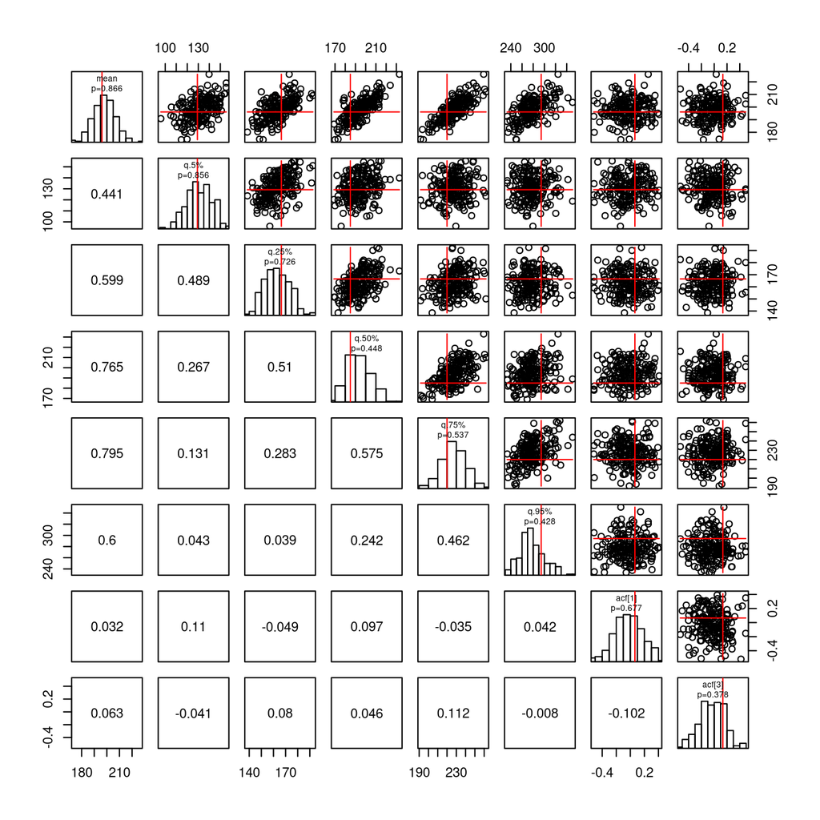

```r
plot(vp_probe)
```

The plot depicts the multivariate distribution of the probes under the model, with the data-values superimposed. On the diagonal, we see the marginal distributions of the individual probes, represented as histograms, with the vertical line signifying the value of the corresponding probe on the data. Above the diagonal, the scatterplots show the pairwise distributions of probes and the crosshairs, the corresponding data-values. Below the diagonal, the panels contains the pairwise correlations among the simulated probes.

## Next steps

To this point, we’ve seen how to implement POMP models, simulate them, to compute and maximize likelihoods, and perform certain kinds of diagnostic checks. The [**pomp** website](https://kingaa.github.io/pomp/) contains more documentation, including the full package manual, and a variety of tutorials and short courses. The package itself contains a number of built-in examples and datasets that can be explored.

**pomp** provides a large toolbox of different inference methods, only a few of which have been explored here. In particular, the package provides other methods for parameter estimation, both in the frequentist and Bayesian modes. See for example (`abc`, `pmcmc`, `probe.match`, `spect.match`, `nlf`, `enkf`, `bsmc2`). It also provides a variety of tools for model checking (`spect`, `nlf`). It is frequently the case that an approach that makes use of more than one approach has advantages over more “purist” approaches: the main goal of the package is to facilitate effective inference by bringing a variety of tools, with complementary strengths and weaknesses, to the user in a common format.

Although the goal of this document has been to introduce the beginner to the package through a display of the **pomp** toolbox in the context of a rudimentary and incomplete data analysis of a short time series with toy models, it is important to realize that these tools have proven their utility on some extremely challenging problems, including some for which other existing methods are either less efficient or entirely infeasible. The [bibliography](https://kingaa.github.io/pomp/biblio.html) has links to peer-reviewed publications that have used these methods.

## Session information

This document was produced with the following software versions:

| **R** | 4.6.1 |
| --- | --- |
| **pomp** | 6.4.0.5 |
| **circumstance** | 0.0.10.1 |
| **coda** | 0.19.4.1 |
| **foreach** | 1.5.2 |
| **doFuture** | 1.3.0 |
| **subplex** | 1.9 |
| **tidyverse** | 2.0.0 |

## References

Andrieu C, Doucet A, Holenstein R (2010). “Particle Markov Chain Monte Carlo Methods.” *Journal of the Royal Statistical Society, Series B*, **72**(3), 269–342. [https://doi.org/10.1111/j.1467-9868.2009.00736.x.](https://doi.org/10.1111/j.1467-9868.2009.00736.x)

Arulampalam MS, Maskell S, Gordon N, Clapp T (2002). “A Tutorial on Particle Filters for Online Nonlinear, Non-Gaussian Bayesian Tracking.” *IEEE Transactions on Signal Processing*, **50**, 174–188. [https://doi.org/10.1109/78.978374.](https://doi.org/10.1109/78.978374)

Ionides EL, Bretó C, King AA (2006). “Inference for Nonlinear Dynamical Systems.” *Proceedings of the National Academy of Sciences*, **103**(49), 18438–18443. [https://doi.org/10.1073/pnas.0603181103.](https://doi.org/10.1073/pnas.0603181103)

Ionides Edward L, Nguyen D, Atchadé Y, Stoev S, King AA (2015). “Inference for Dynamic and Latent Variable Models via Iterated, Perturbed Bayes Maps.” *Proceedings of the National Academy of Sciences*, **112**(3), 719–724. [https://doi.org/10.1073/pnas.1410597112.](https://doi.org/10.1073/pnas.1410597112)

McCleery RH, Perrins CM (1991). “Effects of Predation on the Numbers of Great Tits *Parus Major*.” In *Bird population studies. Relevence to conservation and management* 129–147. Oxford University Press, Oxford. [https://doi.org/10.1093/oso/9780198577300.003.0006.](https://doi.org/10.1093/oso/9780198577300.003.0006)

Ricker WE (1954). “Stock and Recruitment.” *Journal of the Fisheries Research Board of Canada*, **11**, 559–623. [https://doi.org/10.1139/f54-039.](https://doi.org/10.1139/f54-039)

[**pomp** documentation index](https://kingaa.github.io/pomp/docs.html)  
[**pomp** manual](https://kingaa.github.io/manuals/pomp/)  
[**pomp** homepage](https://kingaa.github.io/pomp/)  
Top Back Close